# Validation of Hepatitis B viral count at ICL

These are the results of the validation of the Hepatitis B viral count at Internatinal Clinical Laboratories, Addis Abeba. Serum specimens were run on the Abbott m2000 system and results were compared with results of the same specimens obtained from Bioscientia (Germany).

In a summary. 'Zero' values have been changed to '1' in order to be able to plot in logaritmic scale. The lower limit of detection (LLD) at ICL is 10 IU/ml and the LLD at Bioscientie os 20IU/ml. So, if the result is <20IU/ml, the detected value could be anywhere between 1 and 20. Therefore, the lower limit of detection has been set for ICL at '5 IU/ml' and '10 IU/ml' for Bioscientia.

```r
summary(HepB_ICL)
```

```
##       PIN            Bioscientia            ICL
##  Min.   :1.41e+10   Min.   :1.00e+00   Min.   :1.00e+00
##  1st Qu.:1.41e+10   1st Qu.:1.38e+02   1st Qu.:6.17e+02
##  Median :1.41e+10   Median :2.97e+03   Median :2.55e+03
##  Mean   :1.41e+10   Mean   :1.75e+07   Mean   :2.28e+07
##  3rd Qu.:1.41e+10   3rd Qu.:1.70e+05   3rd Qu.:1.05e+06
##  Max.   :1.41e+10   Max.   :1.70e+08   Max.   :2.88e+08
```

```r
head(HepB_ICL)
```

```
##         PIN Bioscientia      ICL
## 1 1.409e+10           1      182
## 2 1.409e+10        3476     3476
## 3 1.411e+10        2970     2552
## 4 1.411e+10       96680 20892961
## 5 1.411e+10     1525000  1047129
## 6 1.411e+10         909      832
```

To make it more easy, the set of values from Bioscientia = 'x'. The set of values from ICL = 'y'

Calculate the means and difference between the two sets (x and y)

```r
# derive difference
mean(x)
```

```
## [1] 17474765
```

```r
mean(y)
```

```
## [1] 22816346
```

```r
# mean Bio - mean ICL
mean(x)-mean(y)
```

```
## [1] -5341581
```

Because n=17 is small, the distribution of the differences should be approximately normal. Check using a boxplot and QQ plot. There is some skew.

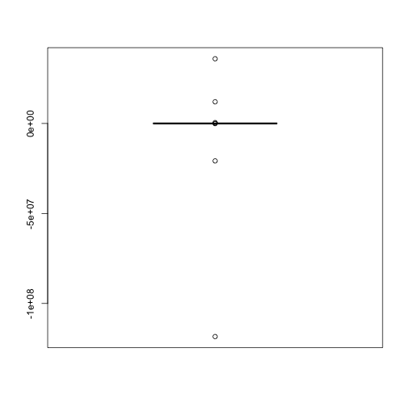

```r
HepB_ICL$diff <- x-y
# HepB_ICL$diff

boxplot(HepB_ICL$diff)
```

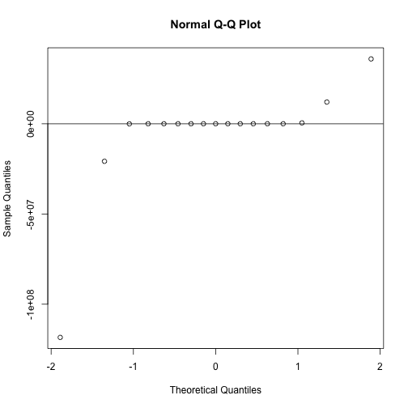

```r
qqnorm(HepB_ICL$diff)
qqline(HepB_ICL$diff)
```

Shaphiro test of normality.

```r
shapiro.test(HepB_ICL$diff)
```

```
##
##  Shapiro-Wilk normality test
##
## data:  HepB_ICL$diff
## W = 0.4978, p-value = 1.242e-06
```

The normality test gives p < 0.003, which is small, so we reject the null hypothesis that the values are distributed normally.

This means that we cannot use the student t-test. Instead, use the Mann-Whitney-Wilcoxon Test, we can decide whether the population distributions are identical without assuming them to follow the normal distribution.

```r
wilcox.test(x, y, paired = TRUE)
```

```
##
##  Wilcoxon signed rank test with continuity correction
##
## data:  x and y
## V = 53, p-value = 0.712
## alternative hypothesis: true location shift is not equal to 0
```

Just to see what happens in the Student T-test. A paired t-test: one sample, two tests H0 = no difference; H1 = mean of 2 tests are different mu= a number indicating the true value of the mean (or difference in means if you are performing a two sample test).

```r
t.test(x, y, mu=0, paired=T, alternative="greater")
```

```
##
##  Paired t-test
##
## data:  x and y
## t = -0.7098, df = 16, p-value = 0.756
## alternative hypothesis: true difference in means is greater than 0
## 95 percent confidence interval:
##  -18479684       Inf
## sample estimates:
## mean of the differences
##                -5341581
```

p = 0.756. Because p is larger than alpha, we do NOT reject H0. In other words, it is unlikely the observed agreements happened by chance. However, because the populations do not have a normal distribution, we can not use the outcome if this test.

```r
# correlation of the two methods
cor.test(x, y,
         alternative = c("two.sided", "less", "greater"),
         method = c("pearson", "kendall", "spearman"),
         exact = NULL, conf.level = 0.95)
```

```
##
##  Pearson's product-moment correlation
##
## data:  x and y
## t = 10.65, df = 15, p-value = 2.163e-08
## alternative hypothesis: true correlation is not equal to 0
## 95 percent confidence interval:
##  0.8375 0.9785
## sample estimates:
##    cor
## 0.9398
```

Plotting the two methods using logarithmic scales.

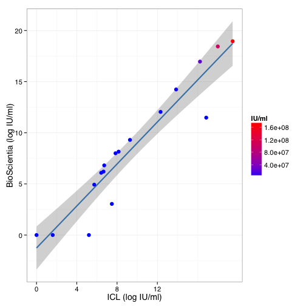

```r
g <- ggplot(HepB_ICL, aes(log(ICL), log(Bioscientia)))


# add layers
g +
  geom_smooth(method="lm", se=TRUE, col="steelblue", size = 1) +
  geom_point(size = 3, aes(colour = x)) +
  scale_colour_gradient("IU/ml", high = "red", low = "blue", space = "Lab") +
  labs(y = "BioScientia (log IU/ml)") +
  labs(x = "ICL (log IU/ml)") +
  theme_bw(base_family = "Helvetica", base_size = 14) +
  scale_x_continuous(breaks=c(0,4,8,12,16))
```

Summary data on the correlation line.

```r
regmod <- lm(y~x, data=HepB_ICL)
summary(regmod)
```

```
##
## Call:
## lm(formula = y ~ x, data = HepB_ICL)
##
## Residuals:
##       Min        1Q    Median        3Q       Max
## -76876353   2014332   2019212   2019335  48814171
##
## Coefficients:
##              Estimate Std. Error t value Pr(>|t|)
## (Intercept) -2.02e+06   6.46e+06   -0.31     0.76
## x            1.42e+00   1.33e-01   10.65  2.2e-08 ***
## ---
## Signif. codes:  0 '***' 0.001 '**' 0.01 '*' 0.05 '.' 0.1 ' ' 1
##
## Residual standard error: 24800000 on 15 degrees of freedom
## Multiple R-squared:  0.883,  Adjusted R-squared:  0.875
## F-statistic:  113 on 1 and 15 DF,  p-value: 2.16e-08
```

The Bland-Altman Analysis. To check if there is a bias.

```
##    Bioscientia       ICL       diff
## 1            1       182       -181
## 2         3476      3476          0
## 3         2970      2552        418
## 4        96680  20892961  -20796281
## 5      1525000   1047129     477871
## 6          909       832         77
## 7     23260000  11220185   12039815
## 8          441       617       -176
## 9    102000000  66069345   35930655
## 10   170000000 288403150 -118403150
## 11         494       776       -282
## 12           1         5         -4
## 13      169900    223872     -53972
## 14         138       309       -171
## 15          21      1778      -1757
## 16           1         1          0
## 17       10980     10715        265
```

[output not shown]

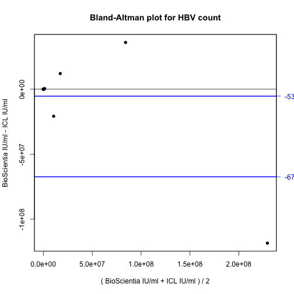

```
##
## Limits of agreement:
## BioScientia IU/ml - ICL IU/ml                    2.5% limit
##                      -5341581                     -67395870
##                   97.5% limit                      SD(diff)
##                      56712709                      31027145
```

```r
BlandAltman(x, y,
            x.name = "BioScientia IU/ml",
            y.name = "ICL IU/ml",
            maintit = "Bland-Altman plot for HBV count",
            cex = 1,
            pch = 16,
            col.points = "black",
            col.lines = "blue",
            limx = NULL,
            limy = NULL,
            ymax = NULL,
            eqax = FALSE,
            xlab = NULL,
            ylab = NULL,
            print = TRUE,
            reg.line = FALSE,
            digits = 2,
            mult = FALSE)
```